# Lung Cancer Analysis

```r
if (!requireNamespace("BiocManager", quietly = TRUE))
  install.packages("BiocManager")
BiocManager::install()
if (!requireNamespace("BiocManager", quietly = TRUE))
  install.packages("BiocManager")

BiocManager::install("limma")
BiocManager::install("Glimma")
BiocManager::install("edgeR")
BiocManager::install("Homo.sapiens")
```

```r
BiocManager::install("heatmap.plus")
library(limma)
library(Glimma)
library(edgeR)
library(Homo.sapiens)
```

- DATA PACKAGING -> READING IN COUNT DATA

Setting up the working directory. All the files to be uploaded should be here.

```r
setwd("/Users/aasthadave/desktop/Final510/txt")
```

```r
files <- c("6476b6b8-7e7e-44ac-9869-c93b654458a5.htseq.counts.txt", "7ea958f2-f45d-4549-9d45-07c51eebae99.htseq.counts.txt",
           "4f361433-9254-4f3e-9e1b-39d665e17398.htseq.counts.txt", "6d53bf05-58d4-4633-b2da-0dd71d89ee91.htseq.counts.txt",
           "7f73a1b0-8b36-425c-90d6-c1daf18e4a18.htseq.counts.txt", "9f64d4a4-e4ad-4ee1-89a1-049b78956bcb.htseq.counts.txt",
           "19f441a5-6db0-4ea3-8241-728b5e3fb86a.htseq.counts.txt", "59e22196-c04d-46c9-b16f-98858dca67d1.htseq.counts.txt",
           "68acaa5e-6a27-499f-925d-710af9d30710.htseq.counts.txt", "314b3b08-27e7-4936-a7d9-2dce4e4d3db7.htseq.counts.txt",
           "994ba708-9a28-4e86-8dc0-f3626cb26b1e.htseq.counts.txt", "37616fc4-9761-47f8-a819-9a9ed6564b21.htseq.counts.txt",
           "11180707-ca2c-4933-bb99-df496bffcafb.htseq.counts.txt", "a059cf08-5046-4a79-a82f-c07da2955035.htseq.counts.txt",
           "a571b078-2572-4b5a-b9be-52ad05085e1c.htseq.counts.txt", "ac3af473-48c0-4fb1-9f31-56ba6fa744c1.htseq.counts.txt",
           "c71da743-de94-46d0-9ec0-fed1574845b9.htseq.counts.txt", "ce786209-c77d-47e0-95a6-20c036bed8b3.htseq.counts.txt",
           "f204f6b8-03fb-4464-922d-de9fffeff9d5.htseq.counts.txt", "f561e8fc-3ed9-4d8f-be9f-800966251738.htseq.counts.txt",
           "90af0faf-3e8c-4741-bf49-f87a5b21d54c.htseq.counts.txt", "16c42b24-fcaf-43e2-8f52-d7488f82257b.htseq.counts.txt", "7b3fca6d-8886-46b4-99fa-cc87e6790c9f.htseq.counts.txt", "9d7486ce-efb9-413f-80b1-e47971625875.htseq.counts.txt", "43b969ef-d7cb-4c8d-b6de-fdfa48b8edff.htseq.counts.txt", "8377de42-868b-4748-bbe0-b66827e274bf.htseq.counts.txt",
           "96717cca-f561-43ee-8fac-74c9aa43c202.htseq.counts.txt", "a24d07c0-9b91-4538-96d2-f97544f4dbb0.htseq.counts.txt",
           "ac5bc405-b210-4bf3-a4e6-6ff071aa59c7.htseq.counts.txt", "ae3d90f2-e69b-4711-8e09-368c732cdc23.htseq.counts.txt",
           "b32ed1d3-c9f1-42c7-ad2a-32794591a839.htseq.counts.txt", "bf8dd7a7-37b1-4a81-9554-d63fdf2fe4f1.htseq.counts.txt",
           "c9381f51-ec09-4487-88a4-8e94452e4893.htseq.counts.txt", "daefaee3-eb0e-4cf8-8807-f544128345e7.htseq.counts.txt",
           "dd5e64ab-9ed8-4259-9d68-598853fa41f4.htseq.counts.txt", "ebe06b50-91d3-4a79-bc8f-6564742c1652.htseq.counts.txt",
           "f67ccdd6-1577-45fd-9e49-251b289d1179.htseq.counts.txt", "fe232ef7-4d50-4dfc-bea1-6b6a7a3e4135.htseq.counts.txt",
           "9bc59130-b619-4ac7-a87e-7342786311d0.htseq.counts.txt", "12d2b9fa-1921-4033-bdb9-7e114c0d7812.htseq.counts.txt")
read.delim(files[1], nrow=5, header=FALSE)
```

| V1 | V2 |
| --- | --- |
| ENSG00000000003.13 | 4836 |
| ENSG00000000005.5 | 3 |
| ENSG00000000419.11 | 1409 |
| ENSG00000000457.12 | 546 |
| ENSG00000000460.15 | 437 |

```r
x <- readDGE(files, columns=c(1,2))
```

```
## Meta tags detected: __no_feature, __ambiguous, __too_low_aQual, __not_aligned, __alignment_not_unique
```

```r
class(x)
```

```
## [1] "DGEList"
## attr(,"package")
## [1] "edgeR"
```

```r
dim(x)
```

```
## [1] 60487    40
```

-> ORGANIZING SAMPLE INFORMATION We are diving the sample into two groups here.

```r
samplenames <- colnames(x)
colnames(x) <- samplenames

group <- c(rep("Whites", 20), rep("African_Americans", 20 ))
Gender <- c("Female", "Female", "Male", "male", "male", "male", "male", "male", "male", "male",
                "male", "high", "male", "male", "male", "high", "male", "male", "male", "male",
                "Female", "Female", "Female", "Female", "Female", "male", "male", "male", "male", "male",
                "male", "male", "male", "male", "male", "male", "male", "male", "male", "male")
x$samples$Gender <- Gender

x$samples$group <- group
x$samples
```

|  | files | group | lib.size | norm.factors | Gender |
| --- | --- | --- | --- | --- | --- |
| 6476b6b8-7e7e-44ac-9869-c93b654458a5.htseq.counts | 6476b6b8-7e7e-44ac-9869-c93b654458a5.htseq.counts.txt | Whites | 42300587 | 1 | Female |
| 7ea958f2-f45d-4549-9d45-07c51eebae99.htseq.counts | 7ea958f2-f45d-4549-9d45-07c51eebae99.htseq.counts.txt | Whites | 111380023 | 1 | Female |
| 4f361433-9254-4f3e-9e1b-39d665e17398.htseq.counts | 4f361433-9254-4f3e-9e1b-39d665e17398.htseq.counts.txt | Whites | 51031062 | 1 | Male |
| 6d53bf05-58d4-4633-b2da-0dd71d89ee91.htseq.counts | 6d53bf05-58d4-4633-b2da-0dd71d89ee91.htseq.counts.txt | Whites | 36765677 | 1 | male |
| 7f73a1b0-8b36-425c-90d6-c1daf18e4a18.htseq.counts | 7f73a1b0-8b36-425c-90d6-c1daf18e4a18.htseq.counts.txt | Whites | 75710975 | 1 | male |
| 9f64d4a4-e4ad-4ee1-89a1-049b78956bcb.htseq.counts | 9f64d4a4-e4ad-4ee1-89a1-049b78956bcb.htseq.counts.txt | Whites | 41864469 | 1 | male |
| 19f441a5-6db0-4ea3-8241-728b5e3fb86a.htseq.counts | 19f441a5-6db0-4ea3-8241-728b5e3fb86a.htseq.counts.txt | Whites | 147076621 | 1 | male |
| 59e22196-c04d-46c9-b16f-98858dca67d1.htseq.counts | 59e22196-c04d-46c9-b16f-98858dca67d1.htseq.counts.txt | Whites | 77230965 | 1 | male |
| 68acaa5e-6a27-499f-925d-710af9d30710.htseq.counts | 68acaa5e-6a27-499f-925d-710af9d30710.htseq.counts.txt | Whites | 74336689 | 1 | male |
| 314b3b08-27e7-4936-a7d9-2dce4e4d3db7.htseq.counts | 314b3b08-27e7-4936-a7d9-2dce4e4d3db7.htseq.counts.txt | Whites | 58659069 | 1 | male |

[output cut: 30 more lines]

Since the ENSEMBL IDs are present in Homo.sapiens library with a suffix after ‘.’. We want to remove the suffix after the ‘.’. We use regular expression in our next step along with gsub function.

```r
geneid <- rownames(x)
geneid <-gsub("\\.[0-9]*$","", geneid)
head(geneid)
```

```
## [1] "ENSG00000000005" "ENSG00000000419" "ENSG00000000457" "ENSG00000000460"
## [5] "ENSG00000000938" "ENSG00000000971"
```

-> ORGANIZING GENE ANNOTATIONS

The ENSEMBL gene IDs in our dataset were annotated using Homo.sapiens package to retrieve the associated information like gene symbol and chromosome numbers.

```r
genes <- select(Homo.sapiens, keys=geneid, columns=c("SYMBOL", "TXCHROM"),
                keytype="ENSEMBL")
head(genes)
```

|  | ENSEMBL | SYMBOL | TXCHROM |
| --- | --- | --- | --- |
| 1 | ENSG00000000005 | TNMD | chrX |
| 2 | ENSG00000000419 | DPM1 | chr20 |
| 3 | ENSG00000000457 | SCYL3 | chr1 |
| 4 | ENSG00000000460 | C1orf112 | chr1 |
| 5 | ENSG00000000938 | FGR | chr1 |
| 6 | ENSG00000000971 | CFH | chr1 |

There can be genes that can map to multiple chromosomes. For eg, a gene XYZ may stretch from chr1 and chr4. Hence the gene will show up in both the chromosomes. To avoid this duplication, either we can select one of the chromosome to associate this gene or choose the chromosome where it appears first. Here we are using the latter option.

```r
genes <- genes[!duplicated(genes$ENSEMBL),]
x$genes <- genes
x
```

```
## An object of class "DGEList"
## $samples
##                                                                                                   files
## 6476b6b8-7e7e-44ac-9869-c93b654458a5.htseq.counts 6476b6b8-7e7e-44ac-9869-c93b654458a5.htseq.counts.txt
## 7ea958f2-f45d-4549-9d45-07c51eebae99.htseq.counts 7ea958f2-f45d-4549-9d45-07c51eebae99.htseq.counts.txt
## 4f361433-9254-4f3e-9e1b-39d665e17398.htseq.counts 4f361433-9254-4f3e-9e1b-39d665e17398.htseq.counts.txt
## 6d53bf05-58d4-4633-b2da-0dd71d89ee91.htseq.counts 6d53bf05-58d4-4633-b2da-0dd71d89ee91.htseq.counts.txt
## 7f73a1b0-8b36-425c-90d6-c1daf18e4a18.htseq.counts 7f73a1b0-8b36-425c-90d6-c1daf18e4a18.htseq.counts.txt
##                                                    group  lib.size norm.factors
## 6476b6b8-7e7e-44ac-9869-c93b654458a5.htseq.counts Whites  42300587            1
## 7ea958f2-f45d-4549-9d45-07c51eebae99.htseq.counts Whites 111380023            1
## 4f361433-9254-4f3e-9e1b-39d665e17398.htseq.counts Whites  51031062            1
## 6d53bf05-58d4-4633-b2da-0dd71d89ee91.htseq.counts Whites  36765677            1
## 7f73a1b0-8b36-425c-90d6-c1daf18e4a18.htseq.counts Whites  75710975            1
##                                                   Gender
## 6476b6b8-7e7e-44ac-9869-c93b654458a5.htseq.counts Female
## 7ea958f2-f45d-4549-9d45-07c51eebae99.htseq.counts Female
## 4f361433-9254-4f3e-9e1b-39d665e17398.htseq.counts   Male
## 6d53bf05-58d4-4633-b2da-0dd71d89ee91.htseq.counts   male
## 7f73a1b0-8b36-425c-90d6-c1daf18e4a18.htseq.counts   male
## 35 more rows ...
##
## $counts
##                     Samples
## Tags                 6476b6b8-7e7e-44ac-9869-c93b654458a5.htseq.counts
##   ENSG00000000005.5                                                  3
##   ENSG00000000419.11                                              1409
##   ENSG00000000457.12                                               546
##   ENSG00000000460.15                                               437
##   ENSG00000000938.11                                               409
##                     Samples
## Tags                 7ea958f2-f45d-4549-9d45-07c51eebae99.htseq.counts
##   ENSG00000000005.5                                                 16
##   ENSG00000000419.11                                              1832
##   ENSG00000000457.12                                               810
##   ENSG00000000460.15                                               449
##   ENSG00000000938.11                                              2597
##                     Samples
## Tags                 4f361433-9254-4f3e-9e1b-39d665e17398.htseq.counts
##   ENSG00000000005.5                                                  0
```

[output cut: 258 more lines]

```
##   ENSG00000000005.5                                                  3
##   ENSG00000000419.11                                              1726
##   ENSG00000000457.12                                              1340
##   ENSG00000000460.15                                               524
##   ENSG00000000938.11                                               605
## 60482 more rows ...
##
## $genes
##           ENSEMBL   SYMBOL TXCHROM
## 1 ENSG00000000005     TNMD    chrX
## 2 ENSG00000000419     DPM1   chr20
## 3 ENSG00000000457    SCYL3    chr1
## 4 ENSG00000000460 C1orf112    chr1
## 5 ENSG00000000938      FGR    chr1
## 60482 more rows ...
```

- DATA PREPROCESSING -> TRANSFORMATIONS FROM A RAW SCALE

The data is transformed in a more usable form. We calculate counts per milllion (CPM) and log of counts per million (LCPM):

```r
cpm <- cpm(x)
lcpm <- cpm(x, log=TRUE)

L <- mean(x$samples$lib.size) * 1e-6
M <- median(x$samples$lib.size) * 1e-6
c(L, M)
```

```
## [1] 71.77702 66.14591
```

```r
summary(lcpm)
```

```
##  6476b6b8-7e7e-44ac-9869-c93b654458a5.htseq.counts
##  Min.   :-5.1654
##  1st Qu.:-5.1654
##  Median :-4.2792
##  Mean   :-2.1972
##  3rd Qu.: 0.3028
##  Max.   :17.7022
##  7ea958f2-f45d-4549-9d45-07c51eebae99.htseq.counts
##  Min.   :-5.1654
##  1st Qu.:-5.1654
##  Median :-4.7625
##  Mean   :-2.5316
##  3rd Qu.:-0.4577
##  Max.   :18.4000
##  4f361433-9254-4f3e-9e1b-39d665e17398.htseq.counts
##  Min.   :-5.165
##  1st Qu.:-5.165
##  Median :-4.397
##  Mean   :-2.383
##  3rd Qu.:-0.168
##  Max.   :17.793
##  6d53bf05-58d4-4633-b2da-0dd71d89ee91.htseq.counts
##  Min.   :-5.1654
##  1st Qu.:-5.1654
##  Median :-5.1654
##  Mean   :-2.4372
##  3rd Qu.:-0.2922
##  Max.   :18.0595
##  7f73a1b0-8b36-425c-90d6-c1daf18e4a18.htseq.counts
##  Min.   :-5.1654
##  1st Qu.:-5.1654
##  Median :-4.6057
##  Mean   :-2.4266
##  3rd Qu.:-0.4068
##  Max.   :17.8662
##  9f64d4a4-e4ad-4ee1-89a1-049b78956bcb.htseq.counts
##  Min.   :-5.16545
##  1st Qu.:-5.16545
##  Median :-4.27228
##  Mean   :-2.27214
```

[output cut: 225 more lines]

```
##  Max.   :18.1218
##  9bc59130-b619-4ac7-a87e-7342786311d0.htseq.counts
##  Min.   :-5.1654
##  1st Qu.:-5.1654
##  Median :-4.6456
##  Mean   :-2.4303
##  3rd Qu.:-0.4324
##  Max.   :17.9546
##  12d2b9fa-1921-4033-bdb9-7e114c0d7812.htseq.counts
##  Min.   :-5.16545
##  1st Qu.:-5.16545
##  Median :-4.76925
##  Mean   :-2.35505
##  3rd Qu.:-0.01781
##  Max.   :18.30257
```

We remove the malely expressed genes which might reduce the specificty of our program. By running the following code we have segragated the lowly expressed genes.

```r
table(rowSums(x$counts==0)==9)
```

```
##
## FALSE  TRUE
## 59967   520
```

```r
#expression less than 10
```

```r
keep.exprs <- filterByExpr(x, group=group)
x <- x[keep.exprs,, keep.lib.sizes=FALSE]
#filtered number of genes
dim(x)
```

```
## [1] 20449    40
```

The graphical representation of unfiltered data is shown below:

```r
lcpm.cutoff <- log2(10/M + 2/L)
library(RColorBrewer)
nsamples <- ncol(x)
col <- brewer.pal(nsamples, "Paired")
```

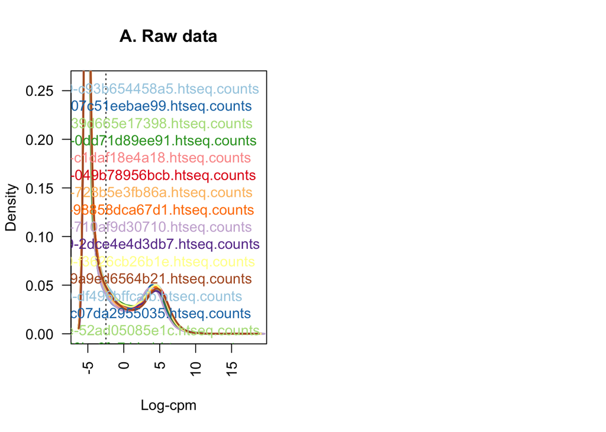

```r
par(mfrow=c(1,2))
plot(density(lcpm[,1]), col=col[1], lwd=2, ylim=c(0,0.26), las=2, main="", xlab="")
title(main="A. Raw data", xlab="Log-cpm")
abline(v=lcpm.cutoff, lty=3)
for (i in 2:nsamples){
  den <- density(lcpm[,i])
  lines(den$x, den$y, col=col[i], lwd=2)
}
legend("topright", samplenames, text.col=col, bty="n")
```

The graphical representation of filtered data is as given below:

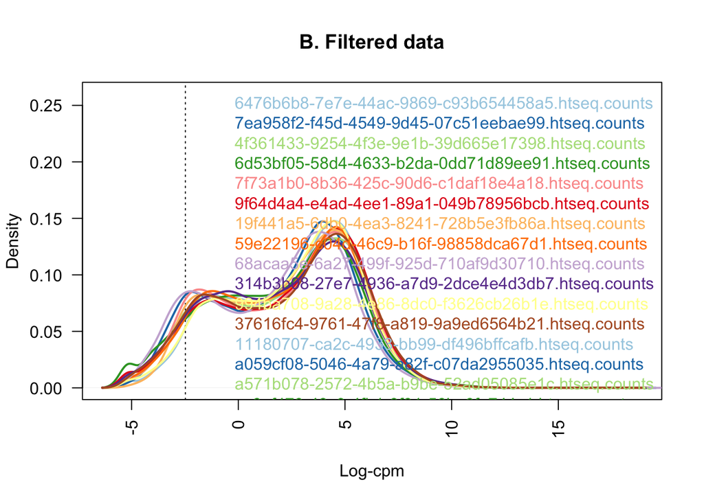

```r
lcpm <- cpm(x, log=TRUE)
plot(density(lcpm[,1]), col=col[1], lwd=2, ylim=c(0,0.26), las=2, main="", xlab="")

title(main="B. Filtered data", xlab="Log-cpm")

abline(v=lcpm.cutoff, lty=3)

for (i in 2:nsamples){
  den <- density(lcpm[,i])
  lines(den$x, den$y, col=col[i], lwd=2)
}
legend("topright", samplenames, text.col=col, bty="n")
```

Normalisation is required to ensure that the expression distributions of each sample are similar across the entire experiment. Here we use the method of Trimmed mean of M values and or that we use the function of calcNormFactors from edgeR package.

```r
#normalizing gene expression distributions
x <- calcNormFactors(x, method = "TMM")
x$samples$norm.factors
```

```
##  [1] 1.2104627 0.7726757 1.0316356 0.9399527 0.9944479 1.1181968 0.9431740
##  [8] 0.9860518 0.6811616 0.9905613 1.0915424 1.0900081 1.0593531 0.9471495
## [15] 0.9170095 0.8773622 0.8741918 1.0094067 0.9821640 0.8690389 1.1123524
## [22] 0.8942912 1.0250047 0.8564600 1.0785875 1.1575030 1.1361885 0.9907464
## [29] 1.0585065 0.9664901 1.1190419 0.9893801 0.9839477 1.2393464 1.1029033
## [36] 1.1825359 1.0209310 1.0622796 0.9290870 0.9805368
```

The graphical representation of unnormalized data

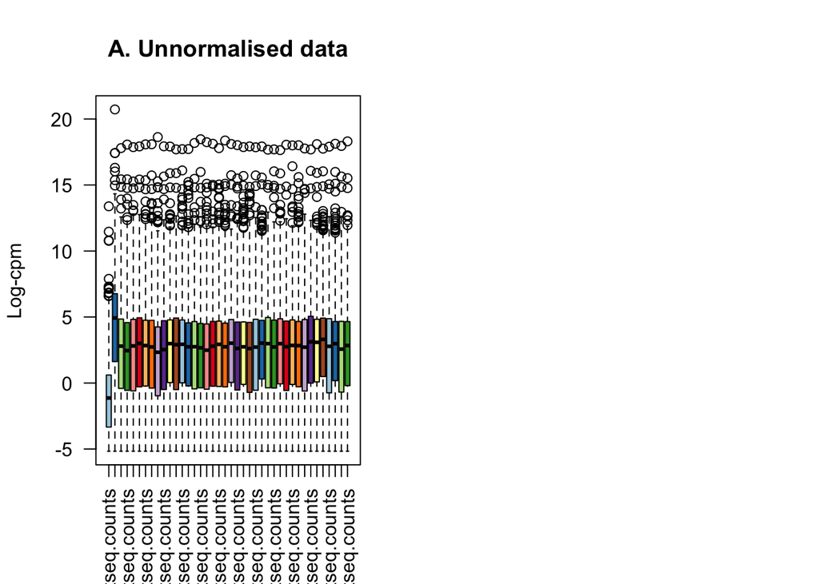

```r
x2 <- x
x2$samples$norm.factors <- 1
x2$counts[,1] <- ceiling(x2$counts[,1]*0.05)
x2$counts[,2] <- x2$counts[,2]*5
par(mfrow=c(1,2))
lcpm <- cpm(x2, log=TRUE)
boxplot(lcpm, las=2, col=col, main="")
title(main="A. Unnormalised data",ylab="Log-cpm")
```

The Graphical representation of normalzed data and we see visible difference in the graph.

```r
x2 <- calcNormFactors(x2)
x2$samples$norm.factors
```

```
##  [1] 0.06953203 4.18093839 1.04922682 0.97899724 1.03152696 1.16722399
##  [7] 1.00054487 1.00524789 0.71776235 1.01932165 1.10310448 1.12679890
## [13] 1.11720936 0.96003530 0.95420035 0.93205792 0.86433691 1.01889153
## [19] 1.01078125 0.94242531 1.14464888 0.94769172 1.03265126 0.90081277
## [25] 1.09823695 1.18445904 1.16138788 1.04746761 1.10913890 0.97493324
## [31] 1.11964528 1.02304398 0.99724675 1.27629473 1.16835046 1.22656003
## [37] 1.01524418 1.09816912 0.94458380 1.00018112
```

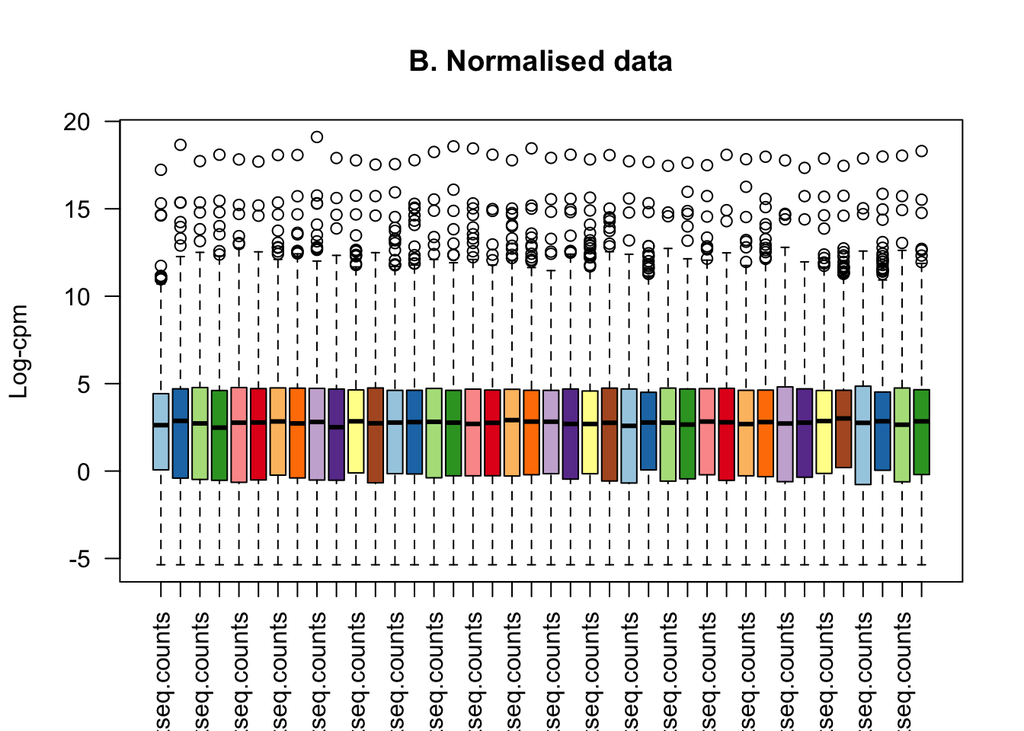

```r
lcpm <- cpm(x2, log=TRUE)
boxplot(lcpm, las=2, col=col, main="")
title(main="B. Normalised data",ylab="Log-cpm")
```

THere are two plots here. 1. whites vs African Americans and the other one is between Males and Females

```r
#unsupervised clustering of samples
lcpm <- cpm(x, log=TRUE)
par(mfrow=c(1,2))
levels(group) <-  brewer.pal(nlevels(group), "Set1")
```

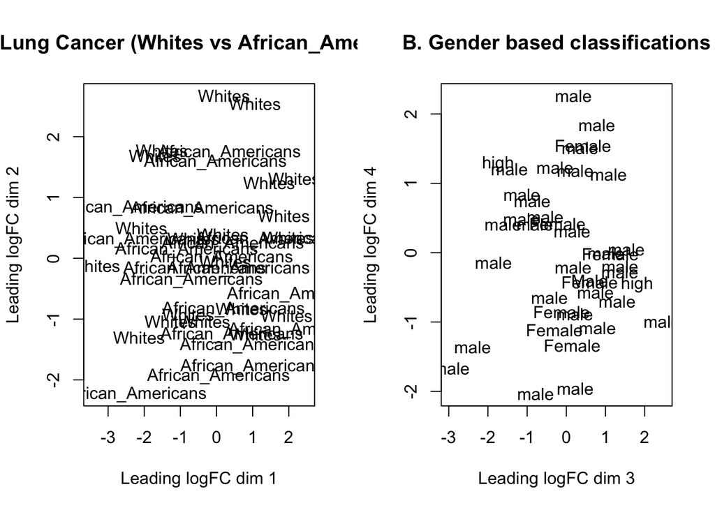

```r
col.group <- as.character(group)
col.group <- c("red","blue")[group]
plotMDS(lcpm, labels=group, col=col.group)

title(main="A. Lung Cancer (Whites vs African_Americans")
col.Gender <- Gender

levels(col.Gender) <-  brewer.pal(nlevels(col.Gender), "Set2")
col.Gender <- as.character(col.Gender)

col.Gender <- c("red","blue")[Gender]
plotMDS(lcpm, labels=Gender, col=col.Gender, dim=c(3,4))
title(main="B. Gender based classifications")
```

For differential Expression analysis we create the design matrix as follwos

```r
#DE analysis
design <- model.matrix(~0+group+Gender)
colnames(design) <- gsub("group", "", colnames(design))
design
```

```
##    African_Americans Whites Genderhigh Gendermale GenderMale
## 1                  0      1          0          0          0
## 2                  0      1          0          0          0
## 3                  0      1          0          0          1
## 4                  0      1          0          1          0
## 5                  0      1          0          1          0
## 6                  0      1          0          1          0
## 7                  0      1          0          1          0
## 8                  0      1          0          1          0
## 9                  0      1          0          1          0
## 10                 0      1          0          1          0
## 11                 0      1          0          1          0
## 12                 0      1          1          0          0
## 13                 0      1          0          1          0
## 14                 0      1          0          1          0
```

[output cut: 34 more lines]

Storing the contrast

```r
contr.matrix <- makeContrasts(
  Whites.vs.African_Americans = Whites-African_Americans,
  levels = colnames(design))
contr.matrix
```

```
##                    Contrasts
## Levels              Whites.vs.African_Americans
##   African_Americans                          -1
##   Whites                                      1
##   Genderhigh                                  0
##   Gendermale                                  0
##   GenderMale                                  0
```

Removing heteroscedascity from count data Voom converts raw counts to log CPM values using limma package.THe graph represents the trend with unnormalized data.

```
## An object of class "EList"
## $genes
##           ENSEMBL   SYMBOL TXCHROM
## 2 ENSG00000000419     DPM1   chr20
## 3 ENSG00000000457    SCYL3    chr1
## 4 ENSG00000000460 C1orf112    chr1
## 5 ENSG00000000938      FGR    chr1
## 6 ENSG00000000971      CFH    chr1
## 20444 more rows ...
##
## $targets
##                                                                                                   files
## 6476b6b8-7e7e-44ac-9869-c93b654458a5.htseq.counts 6476b6b8-7e7e-44ac-9869-c93b654458a5.htseq.counts.txt
## 7ea958f2-f45d-4549-9d45-07c51eebae99.htseq.counts 7ea958f2-f45d-4549-9d45-07c51eebae99.htseq.counts.txt
## 4f361433-9254-4f3e-9e1b-39d665e17398.htseq.counts 4f361433-9254-4f3e-9e1b-39d665e17398.htseq.counts.txt
## 6d53bf05-58d4-4633-b2da-0dd71d89ee91.htseq.counts 6d53bf05-58d4-4633-b2da-0dd71d89ee91.htseq.counts.txt
## 7f73a1b0-8b36-425c-90d6-c1daf18e4a18.htseq.counts 7f73a1b0-8b36-425c-90d6-c1daf18e4a18.htseq.counts.txt
##                                                    group lib.size norm.factors
## 6476b6b8-7e7e-44ac-9869-c93b654458a5.htseq.counts Whites 51023076    1.2104627
## 7ea958f2-f45d-4549-9d45-07c51eebae99.htseq.counts Whites 85998233    0.7726757
## 4f361433-9254-4f3e-9e1b-39d665e17398.htseq.counts Whites 52552921    1.0316356
## 6d53bf05-58d4-4633-b2da-0dd71d89ee91.htseq.counts Whites 34495067    0.9399527
## 7f73a1b0-8b36-425c-90d6-c1daf18e4a18.htseq.counts Whites 75200178    0.9944479
##                                                   Gender
## 6476b6b8-7e7e-44ac-9869-c93b654458a5.htseq.counts Female
## 7ea958f2-f45d-4549-9d45-07c51eebae99.htseq.counts Female
## 4f361433-9254-4f3e-9e1b-39d665e17398.htseq.counts   Male
## 6d53bf05-58d4-4633-b2da-0dd71d89ee91.htseq.counts   male
## 7f73a1b0-8b36-425c-90d6-c1daf18e4a18.htseq.counts   male
## 35 more rows ...
##
## $E
##                     Samples
## Tags                 6476b6b8-7e7e-44ac-9869-c93b654458a5.htseq.counts
##   ENSG00000000419.11                                          4.787890
##   ENSG00000000457.12                                          3.421000
##   ENSG00000000460.15                                          3.100061
##   ENSG00000000938.11                                          3.004642
##   ENSG00000000971.14                                          4.290541
##                     Samples
```

[output cut: 306 more lines]

```
## [1,] 2.200045 2.365515
## [2,] 1.753667 2.057569
## [3,] 1.156501 1.412336
## [4,] 1.766289 2.069484
## [5,] 2.428246 2.423337
## 20444 more rows ...
##
## $design
##   African_Americans Whites Genderhigh Gendermale GenderMale
## 1                 0      1          0          0          0
## 2                 0      1          0          0          0
## 3                 0      1          0          0          1
## 4                 0      1          0          1          0
## 5                 0      1          0          1          0
## 35 more rows ...
```

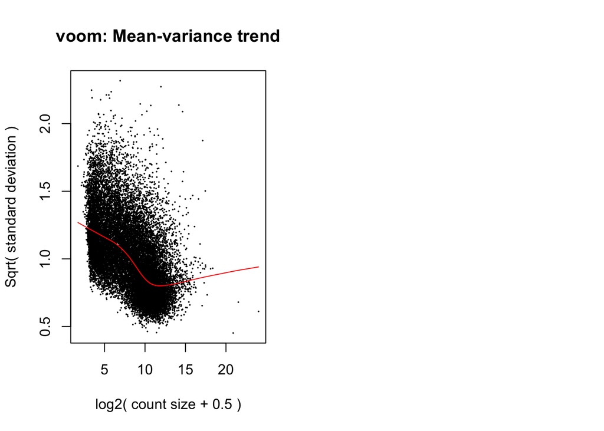

```r
#Removing heteroscedascity from count data

par(mfrow=c(1,2))
v <- voom(x, design, plot=TRUE)
v
```

Here the praph represents voom with normalized data. We get a straight line.

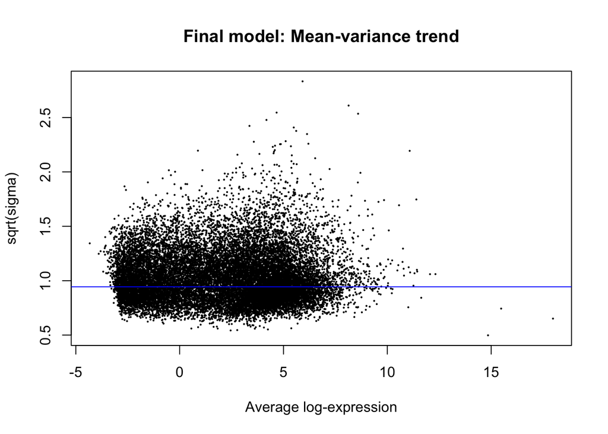

```r
vfit <- lmFit(v, design)
vfit <- contrasts.fit(vfit, contrasts=contr.matrix)
efit <- eBayes(vfit)
plotSA(efit, main="Final model: Mean-variance trend")
```

We get the summary of genes which shows the number of genes that are upregulated and downregulated.

```r
#Examining the number of DE genes
summary(decideTests(efit))
```

```
##        Whites.vs.African_Americans
## Down                             2
## NotSig                       20447
## Up                               0
```

We adjust the lfc - logFC value for the better results of filtering out genes that are up and down regulated.

```r
tfit <- treat(vfit, lfc=0.04)
dt <- decideTests(tfit)
summary(dt)
```

```
##        Whites.vs.African_Americans
## Down                             2
## NotSig                       20447
## Up                               0
```

```r
de.common <- which(dt[,1]!=0)
length(de.common)
```

```
## [1] 2
```

Graphical representation as Venn diagram to represent the differentially expressed genes among the normal genes.

```r
head(tfit$genes$SYMBOL[de.common], n=20)
```

```
## [1] NA         "MTND4P24"
```

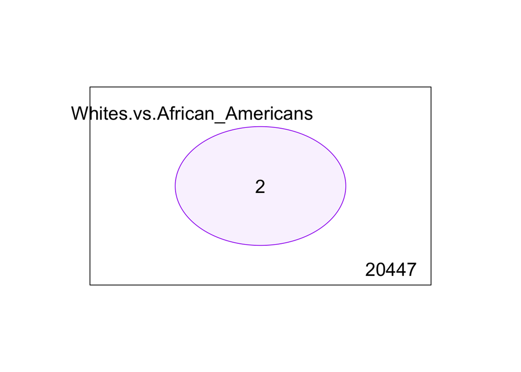

```r
vennDiagram(dt[,1], circle.col=c("purple"))
```

```r
write.fit(tfit, dt, file="results.txt")
```

```r
#Examining individual DE genes from top to bottom

Whites.vs.African_Americans <- topTreat(tfit, coef=1, n=Inf)
head(Whites.vs.African_Americans)
```

|  | ENSEMBL | SYMBOL | TXCHROM | logFC | AveExpr | t | P.Value | adj.P.Val |
| --- | --- | --- | --- | --- | --- | --- | --- | --- |
| ENSG00000232177.1 | ENSG00000232177 | MTND4P24 | NA | -3.4423718 | -1.7011836 | -5.492678 | 2.186716e-06 | 0.03707584 |
| ENSG00000226278.1 | ENSG00000226278 | NA | NA | -4.6954578 | -0.1825091 | -5.349325 | 3.626176e-06 | 0.03707584 |
| ENSG00000113209.8 | ENSG00000113209 | PCDHB5 | chr5 | 2.2215619 | 0.9469148 | 4.714504 | 2.434117e-05 | 0.16591752 |
| ENSG00000239830.1 | ENSG00000239830 | RPS4XP22 | NA | 3.6672481 | -2.1242705 | 4.575331 | 4.106504e-05 | 0.20993477 |
| ENSG00000272977.1 | ENSG00000272977 | NA | NA | 2.1483760 | -1.4332655 | 4.399482 | 6.522638e-05 | 0.26676285 |
| ENSG00000129518.7 | ENSG00000129518 | EAPP | chr14 | 0.7583984 | 4.7313676 | 4.253824 | 7.853111e-05 | 0.26759071 |

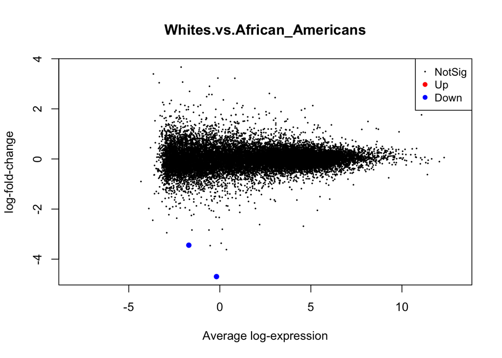

```r
#Useful graphical representations of differential expression results

plotMD(tfit, column=1, status=dt[,1], main=colnames(tfit)[1],
       xlim=c(-8,13))
```

Finally the heatmap for the Differentially expressed genes. The heatmap.plus fuction has been used since we are dealing with larger datasets. The Blue color represents the upregulated genes and white color represents the down regulated genes.

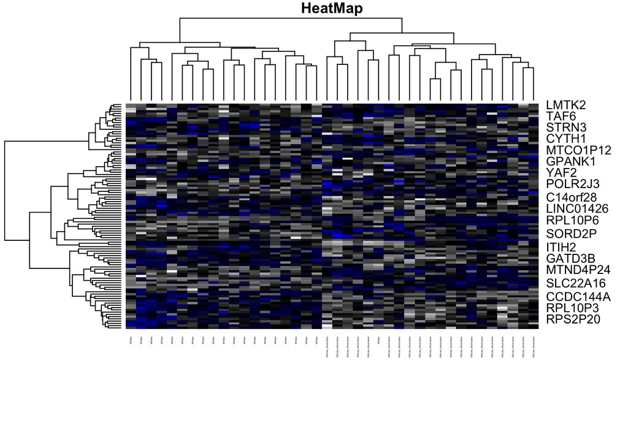

```r
library(gplots)
library(heatmap.plus)

Whites.vs.African_Americans.topgenes <- Whites.vs.African_Americans$ENSEMBL[1:100]
i <- which(v$genes$ENSEMBL %in% Whites.vs.African_Americans.topgenes)
mycol <- colorpanel(100,"white","black","Blue")
par(cex.main=0.8,mar=c(1,1,1,1))
heatmap.plus(lcpm[i,],  scale="row", labRow=v$genes$SYMBOL[i], labCol=group, col=mycol, cexRow=1,cexCol=0.2, margins = c(8,6), main="HeatMap")
```

Gene set testing with camera : It uses Limma package and the camera function is used to check which genes are highly ranked.

```r
load("human_c2_v5p2.rdata")
idx <- ids2indices(Hs.c2, rownames(v$genes))
cam.Whites.vs.African_Americans <- camera(v,idx,design,contrast=contr.matrix[,1])
head(cam.Whites.vs.African_Americans,6)
```

|  | NGenes | Direction | PValue | FDR |
| --- | --- | --- | --- | --- |
| VETTER_TARGETS_OF_PRKCA_AND_ETS1_DN | 12 | Down | 0.0006137109 | 0.9995073 |
| WANG_IMMORTALIZED_BY_HOXA9_AND_MEIS1_DN | 18 | Up | 0.0009118814 | 0.9995073 |
| PID_WNT_SIGNALING_PATHWAY | 19 | Up | 0.0010218968 | 0.9995073 |
| GRADE_COLON_VS_RECTAL_CANCER_UP | 12 | Up | 0.0016608704 | 0.9995073 |
| CAFFAREL_RESPONSE_TO_THC_8HR_5_DN | 8 | Down | 0.0018240685 | 0.9995073 |
| REACTOME_GAP_JUNCTION_TRAFFICKING | 17 | Up | 0.0033027560 | 0.9995073 |

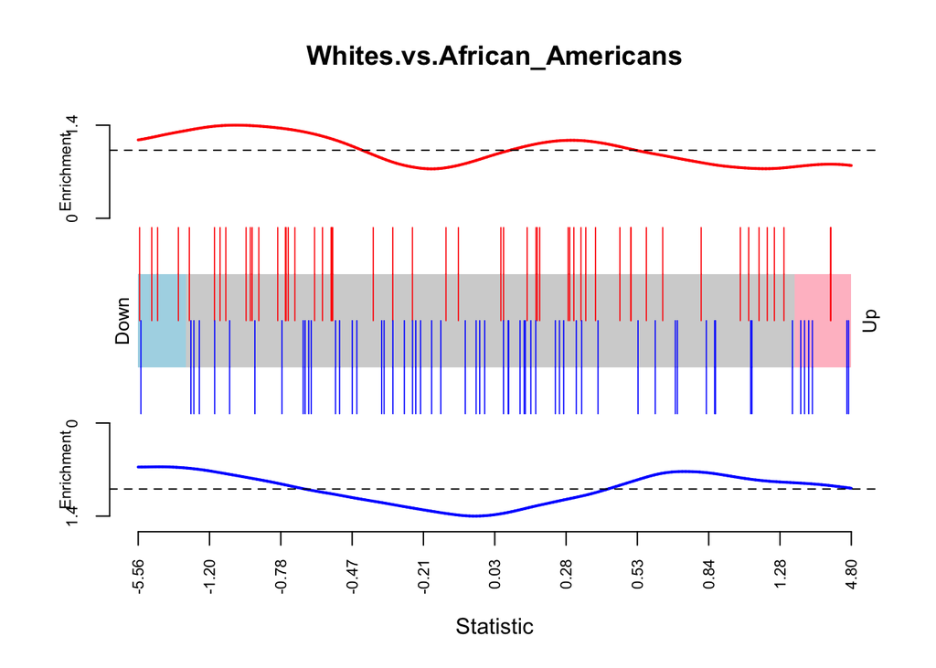

```r
barcodeplot(efit$t[,1], index=idx$LIM_MAMMARY_LUMINAL_MATURE_UP,
            index2=idx$LIM_MAMMARY_LUMINAL_MATURE_DN, main="Whites.vs.African_Americans")
```